# Project: Object detection usind SSD algorithm

- Submitted for review of assignment: Deep learning based model to identify a object in a image"

Naveen A Mohanan 23/4/2018

**Email:**menaveenam@gmail.com.com

**Mno:**9599131811

- Introduction
- Code
- Result

## Introduction

Single Shot MultiBox Detector (by C. Szegedy et al.) was released at the end of November 2016 and reached new records in terms of performance and precision for object detection tasks, scoring over 74% mAP (mean Average Precision) at 59 frames per second on standard datasets such as PascalVOC and COCO.

- Single Shot: this means that the tasks of object localization and classification are done in a single forward pass of the network
- MultiBox: this is the name of a technique for bounding box regression developed by Szegedy et al.
- Detector: The network is an object detector that also classifies those detected objects

## Code

The implementation used below can classify and detect objects of following 20 classes ('aeroplane', 'bicycle', 'bird', 'boat', 'bottle', 'bus', 'car', 'cat', 'chair', 'cow', 'diningtable', 'dog', 'horse', 'motorbike', 'person', 'pottedplant', 'sheep', 'sofa', 'train', 'tvmonitor')

The programs take input as images present in the ip folder in format "IP (n).tiff" where n= no of that image and produces output in format "OP (n).tiff" in op folder.

```python
# Importing the libraries
import torch
from torch.autograd import Variable
import cv2
from data import BaseTransform, VOC_CLASSES as labelmap
from ssd import build_ssd
from matplotlib import pyplot as plt

# Defining a function that will do the detections
def detect(frame, net, transform): # We define a detect function that will take as inputs, a frame, a ssd neural network, and a transformation to be applied on the images, and that will return the frame with the detector rectangle.
    height, width = frame.shape[:2] # We get the height and the width of the frame.
    frame_t = transform(frame)[0] # We apply the transformation to our frame.
    x = torch.from_numpy(frame_t).permute(2, 0, 1) # We convert the frame into a torch tensor.
    x = Variable(x.unsqueeze(0)) # We add a fake dimension corresponding to the batch.
    y = net(x) # We feed the neural network ssd with the image and we get the output y.
    detections = y.data # We create the detections tensor contained in the output y.
    scale = torch.Tensor([width, height, width, height]) # We create a tensor object of dimensions [width, height, width, height].
    for i in range(detections.size(1)): # For every class:
        j = 0 # We initialize the loop variable j that will correspond to the occurrences of the class.
        while detections[0, i, j, 0] >= 0.6: # We take into account all the occurrences j of the class i that have a matching score larger than 0.6.
            pt = (detections[0, i, j, 1:] * scale).numpy() # We get the coordinates of the points at the upper left and the lower right of the detector rectangle.
            cv2.rectangle(frame, (int(pt[0]), int(pt[1])), (int(pt[2]), int(pt[3])), (255, 0, 0), 2) # We draw a rectangle around the detected object.
            cv2.putText(frame, labelmap[i - 1], (int(pt[0]), int(pt[1])), cv2.FONT_HERSHEY_SIMPLEX, 2, (255, 255, 255), 2, cv2.LINE_AA) # We put the label of the class right above the rectangle.
            j += 1 # We increment j to get to the next occurrence.
    return frame # We return the original frame with the detector rectangle and the label around the detected object.

# Creating the SSD neural network
net = build_ssd('test') # We create an object that is our neural network ssd.
net.load_state_dict(torch.load('ssd300_mAP_77.43_v2.pth', map_location = lambda storage, loc: storage)) # We get the weights of the neural network from another one that is pretrained (ssd300_mAP_77.43_v2.pth).

# Creating the transformation
transform = BaseTransform(net.size, (104/256.0, 117/256.0, 123/256.0)) # We create an object of the BaseTransform class, a class that will do the required transformations so that the image can be the input of the neural network.

#reading and writing from folder ip and op
for i in range(10):

    if(i==0):
        print("Output written of image")
        continue
    print(i)
    ippath = str("ip/IP ("+str(i)+").tiff")
    oppath = str("op/OP ("+str(i)+").tiff")
    img = cv2.imread(ippath)
    out = detect(img,net.eval(),transform)
    cv2.imwrite(oppath,out)
print("Done writing op ")
#    cv2.imshow('Lena',out)
#    cv2.waitKey(0)
#    cv2.destroyAllWindows()
#uncomment above three lines to show each op on screen
#press any key to continue after each image
```

```
Output written of image
1
2
3
4
5
6
7
8
9
Done writing op
```

## Results

All the output result will be stored in the op folder with corresponding output image no.

A sample output is provided below.

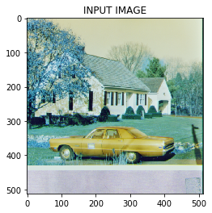

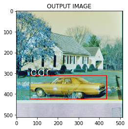

```python
#Displaying an sample ip
ip_eg_path = "ip/IP (9).tiff"
ip = cv2.imread(ip_eg_path)
plt.imshow(ip)
plt.title('INPUT IMAGE')
plt.show()
#Displaying an sample op
op_eg_path = "op/OP (9).tiff"
op = cv2.imread(op_eg_path)
plt.imshow(op)
plt.title('OUTPUT IMAGE')
plt.show()
```